# Homework batch 2

Waheeb Algabri, William Berritt, Kossi Akplaka

## Exersise 6.3

A chemical manufacturing process for a pharmaceutical product was discussed in Sect. 1.4. In this problem, the objective is to understand the relationship between biological measurements of the raw materials (predictors), measurements of the manufacturing process (predictors), and the response of product yield. Biological predictors cannot be changed but can be used to assess the quality of the raw material before processing. On the other hand, manufacturing process predictors can be changed in the manufacturing process. Improving product yield by 1 % will boost revenue by approximately one hundred thousand dollars per batch:

**(a)** - Start R and use these commands to load the data:

The matrix processPredictors contains the 57 predictors (12 describing the input biological material and 45 describing the process predictors) for the 176 manufacturing runs. yield contains the percent yield for each run.

**(b)** - A small percentage of cells in the predictor set contain missing values. Use an imputation function to fill in these missing values (e.g., see Sect. 3.8).

```
## [1] 106
```

```
## [1] 0
```

In the Chemical Manufacturing Process dataset, there were 106 missing values. To impute these missing values, bagged trees were utilized, incorporating all other variables in the dataset for the imputation process.

**(c)** - Split the data into a training and a test set, pre-process the data, and tune a model of your choice from this chapter. What is the optimal value of the performance metric?

```r
# filtering low frequencies
Chemical <- Chemical[, -nearZeroVar(Chemical)]
```

#### Pls model

```
## Partial Least Squares
##
## 144 samples
##  56 predictor
##
## Pre-processing: centered (56), scaled (56)
## Resampling: Cross-Validated (5 fold)
## Summary of sample sizes: 116, 116, 115, 116, 113
## Resampling results across tuning parameters:
##
##   ncomp  RMSE       Rsquared   MAE
##    1     0.8036093  0.4071988  0.6367374
##    2     1.4365546  0.2988402  0.7319426
##    3     0.8395233  0.4864415  0.5885016
##    4     0.7142754  0.5461338  0.5452302
##    5     0.8733816  0.4549832  0.5853743
##    6     0.8593986  0.4679403  0.5870164
##    7     0.9295591  0.4443866  0.6142642
##    8     0.9518653  0.4633677  0.6237792
##    9     0.9986361  0.4559479  0.6401843
##   10     1.0800922  0.4397089  0.6690552
##   11     1.1220520  0.4236919  0.6857109
##   12     1.2363312  0.3888953  0.7297253
##   13     1.3673456  0.3553726  0.7564749
##   14     1.5432401  0.2976818  0.8121070
##   15     1.7549925  0.2420360  0.8675811
##   16     1.9158651  0.2216213  0.9019783
##   17     2.0816786  0.2036341  0.9319581
##   18     2.2610043  0.1858517  0.9675298
##   19     2.3756802  0.1743818  0.9885137
##   20     2.4937091  0.1685774  1.0077022
##
## RMSE was used to select the optimal model using the smallest value.
## The final value used for the model was ncomp = 4.
```

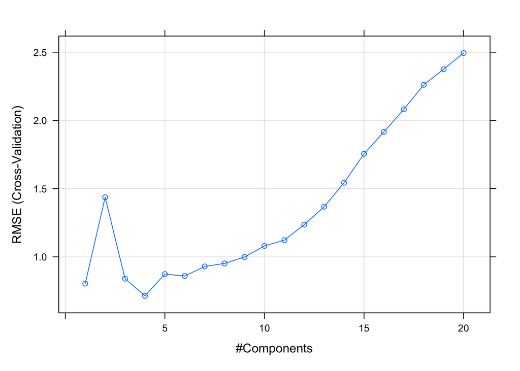

```
##      RMSE  Rsquared       MAE
## 0.7453969 0.4785587 0.6406941
```

#### Elastic Net (enet) model

```
## Elasticnet
##
## 144 samples
##  56 predictor
##
## Pre-processing: centered (56), scaled (56)
## Resampling: Cross-Validated (5 fold)
## Summary of sample sizes: 116, 116, 115, 116, 113
## Resampling results across tuning parameters:
##
##   lambda        fraction  RMSE       Rsquared   MAE
##   0.0000000000  0.05      0.7833362  0.4803890  0.5772312
##   0.0000000000  0.10      0.8848814  0.5141721  0.5778896
##   0.0000000000  0.15      1.3635731  0.2595321  0.7135083
##   0.0000000000  0.20      1.4278320  0.2763265  0.7301754
##   0.0000000000  0.25      1.5247219  0.2447795  0.7583299
##   0.0000000000  0.30      1.5921077  0.2269587  0.7732855
##   0.0000000000  0.35      1.6632894  0.2168947  0.7914762
##   0.0000000000  0.40      1.7074258  0.2235970  0.8067727
##   0.0000000000  0.45      1.5301252  0.2645274  0.7774158
##   0.0000000000  0.50      1.2884935  0.3069665  0.7328894
##   0.0000000000  0.55      1.1070452  0.3510491  0.6904573
##   0.0000000000  0.60      1.0178769  0.3934006  0.6737668
##   0.0000000000  0.65      1.0041851  0.4089037  0.6668299
##   0.0000000000  0.70      0.8835833  0.4436815  0.6506731
##   0.0000000000  0.75      1.4291086  0.2903503  0.7841873
##   0.0000000000  0.80      2.0236309  0.2244944  0.9111890
##   0.0000000000  0.85      2.6451729  0.1898031  1.0396102
##   0.0000000000  0.90      3.2167308  0.1725613  1.1574863
##   0.0000000000  0.95      3.6684923  0.1674405  1.2500651
##   0.0000000000  1.00      4.0847779  0.1651578  1.3342617
##   0.0001000000  0.05      0.7897635  0.4625129  0.5923682
##   0.0001000000  0.10      0.8931464  0.5118901  0.5786504
##   0.0001000000  0.15      1.0508691  0.3729470  0.6343489
##   0.0001000000  0.20      1.3189307  0.2833758  0.6980050
##   0.0001000000  0.25      1.5292273  0.2392506  0.7551900
##   0.0001000000  0.30      1.6074771  0.2289070  0.7783032
##   0.0001000000  0.35      1.6894140  0.2156571  0.7970408
##   0.0001000000  0.40      1.7217599  0.2074435  0.8085167
##   0.0001000000  0.45      1.6526283  0.2220799  0.8002556
```

[output cut: 360 more lines]

```
##   0.1000000000  0.50      0.8057409  0.5224398  0.5631157
##   0.1000000000  0.55      0.8182607  0.5243698  0.5648432
##   0.1000000000  0.60      0.8201020  0.5227242  0.5703707
##   0.1000000000  0.65      0.8043293  0.5128058  0.5724407
##   0.1000000000  0.70      0.8041228  0.5022118  0.5757099
##   0.1000000000  0.75      0.8174206  0.4954939  0.5802727
##   0.1000000000  0.80      0.8571790  0.4778405  0.5934263
##   0.1000000000  0.85      0.8755468  0.4755983  0.5980484
##   0.1000000000  0.90      0.8775178  0.4828228  0.5984011
##   0.1000000000  0.95      0.8728693  0.4938649  0.5951050
##   0.1000000000  1.00      0.8794952  0.4962433  0.5927264
##
## RMSE was used to select the optimal model using the smallest value.
## The final values used for the model were fraction = 0.05 and lambda
##  = 0.0006812921.
```

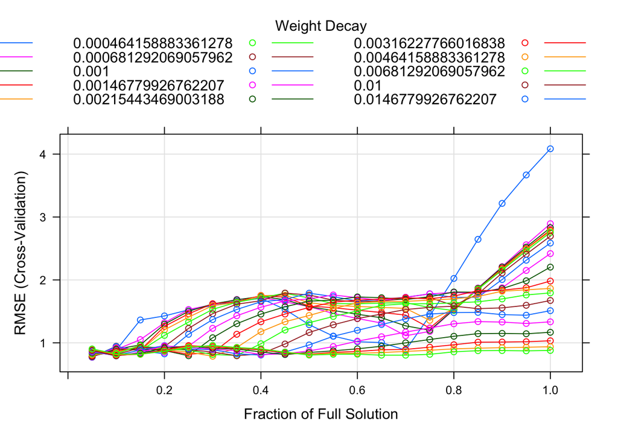

```
##      RMSE  Rsquared       MAE
## 0.6797956 0.6321682 0.5533242
```

#### LARS (Least Angle Regression)

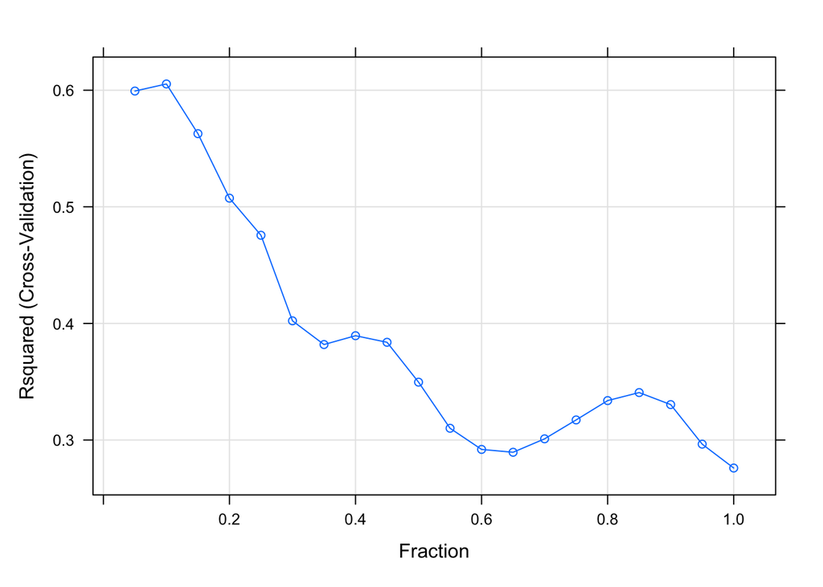

```
##       RMSE   Rsquared        MAE
## 108.580429   0.230893  97.515429
```

#### linear regression model

```
##
## Call:
## lm(formula = Yield ~ ., data = Chemical)
##
## Residuals:
##      Min       1Q   Median       3Q      Max
## -2.20445 -0.53673 -0.03074  0.47917  2.02776
##
## Coefficients: (1 not defined because of singularities)
##                          Estimate Std. Error t value Pr(>|t|)
## (Intercept)            -4.420e-01  8.737e+01  -0.005  0.99597
## BiologicalMaterial01    2.691e-01  3.325e-01   0.809  0.41987
## BiologicalMaterial02   -1.174e-01  1.284e-01  -0.914  0.36243
## BiologicalMaterial03    1.563e-01  2.355e-01   0.664  0.50804
## BiologicalMaterial04   -9.944e-02  5.310e-01  -0.187  0.85177
## BiologicalMaterial05    1.604e-01  1.073e-01   1.495  0.13749
## BiologicalMaterial06    1.257e-02  3.016e-01   0.042  0.96684
## BiologicalMaterial08    4.207e-01  6.380e-01   0.659  0.51094
## BiologicalMaterial09   -8.668e-01  1.372e+00  -0.632  0.52889
## BiologicalMaterial10    4.877e-02  1.385e+00   0.035  0.97197
## BiologicalMaterial11   -8.965e-02  8.262e-02  -1.085  0.28005
## BiologicalMaterial12    3.383e-01  6.345e-01   0.533  0.59492
## ManufacturingProcess01  6.905e-02  9.552e-02   0.723  0.47119
## ManufacturingProcess02  1.424e-02  4.617e-02   0.308  0.75835
## ManufacturingProcess03 -3.192e+00  5.089e+00  -0.627  0.53164
## ManufacturingProcess04  6.390e-02  2.937e-02   2.176  0.03154 *
## ManufacturingProcess05  7.909e-04  3.865e-03   0.205  0.83819
## ManufacturingProcess06  3.786e-02  4.345e-02   0.871  0.38527
## ManufacturingProcess07 -1.857e-01  2.133e-01  -0.870  0.38586
## ManufacturingProcess08 -7.470e-02  2.529e-01  -0.295  0.76819
## ManufacturingProcess09  2.696e-01  1.812e-01   1.488  0.13948
## ManufacturingProcess10 -1.078e-01  5.918e-01  -0.182  0.85571
## ManufacturingProcess11  2.936e-01  7.386e-01   0.397  0.69173
## ManufacturingProcess12  3.310e-05  1.028e-04   0.322  0.74807
## ManufacturingProcess13 -2.465e-01  3.848e-01  -0.641  0.52298
## ManufacturingProcess14  8.983e-04  1.120e-02   0.080  0.93623
## ManufacturingProcess15  1.269e-03  8.989e-03   0.141  0.88794
## ManufacturingProcess16 -5.745e-05  3.166e-04  -0.181  0.85630
## ManufacturingProcess17 -1.631e-01  3.024e-01  -0.540  0.59049
## ManufacturingProcess18  4.453e-03  4.436e-03   1.004  0.31741
```

[output cut: 18 more lines]

```
## ManufacturingProcess37 -7.076e-01  2.918e-01  -2.425  0.01679 *
## ManufacturingProcess38 -1.855e-01  2.422e-01  -0.766  0.44522
## ManufacturingProcess39  7.203e-02  1.310e-01   0.550  0.58335
## ManufacturingProcess40  6.923e-01  6.550e+00   0.106  0.91600
## ManufacturingProcess41  1.236e-01  4.749e+00   0.026  0.97928
## ManufacturingProcess42  4.989e-02  2.112e-01   0.236  0.81364
## ManufacturingProcess43  2.285e-01  1.187e-01   1.925  0.05664 .
## ManufacturingProcess44 -4.337e-01  1.184e+00  -0.366  0.71484
## ManufacturingProcess45  9.594e-01  5.446e-01   1.762  0.08067 .
## ---
## Signif. codes:  0 '***' 0.001 '**' 0.01 '*' 0.05 '.' 0.1 ' ' 1
##
## Residual standard error: 1.042 on 120 degrees of freedom
## Multiple R-squared:  0.7816, Adjusted R-squared:  0.6816
## F-statistic:  7.81 on 55 and 120 DF,  p-value: < 2.2e-16
```

The ordinary linear regression model has a Multiple R2 of 0.7817 and an Adjusted R2 of 0.6816.

#### Ridge regression

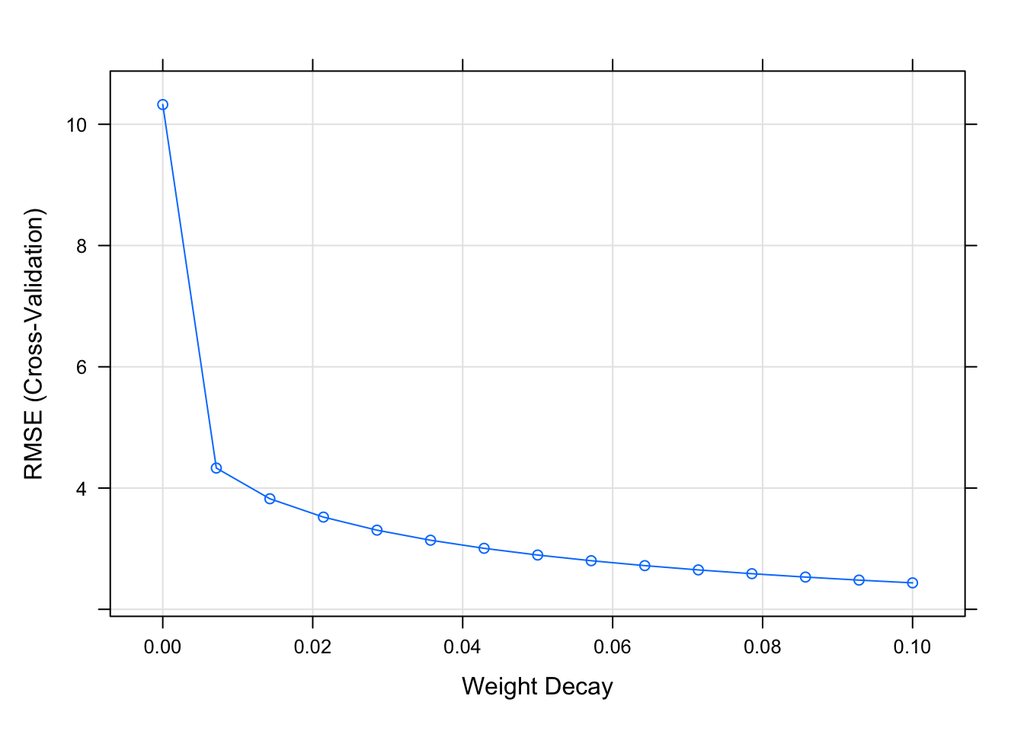

```
##        RMSE    Rsquared         MAE
## 207.5505621   0.2327359 184.0342698
```

###**(d)** - Predict the response for the test set. What is the value of the performance metric and how does this compare with the resampled performance metric on the training set?

Ordinary linear model had the highest $R^2$, but it comes with consequences. Therefore, the `Elastic net` method was chosen as it had the highest $R^2$.

The $R^2$ is 0.632168, which is higher than the training set.

```
##      RMSE  Rsquared       MAE
## 0.6797956 0.6321682 0.5533242
```

```
## loess r-squared variable importance
##
##   only 20 most important variables shown (out of 56)
##
##                        Overall
## ManufacturingProcess32  100.00
## BiologicalMaterial06     94.06
## BiologicalMaterial03     81.27
## ManufacturingProcess13   80.63
## ManufacturingProcess36   80.11
## BiologicalMaterial02     76.04
## ManufacturingProcess17   75.92
## ManufacturingProcess31   73.75
## ManufacturingProcess09   73.04
## BiologicalMaterial12     69.48
## ManufacturingProcess06   66.27
## BiologicalMaterial11     59.72
## ManufacturingProcess33   58.34
## ManufacturingProcess29   54.74
## BiologicalMaterial04     53.93
## BiologicalMaterial01     45.62
## BiologicalMaterial08     44.93
## ManufacturingProcess11   44.03
## BiologicalMaterial09     40.88
## ManufacturingProcess30   38.14
```

### **(f)** - Explore the relationships between each of the top predictors and the re- sponse. How could this information be helpful in improving yield in future runs of the manufacturing process?

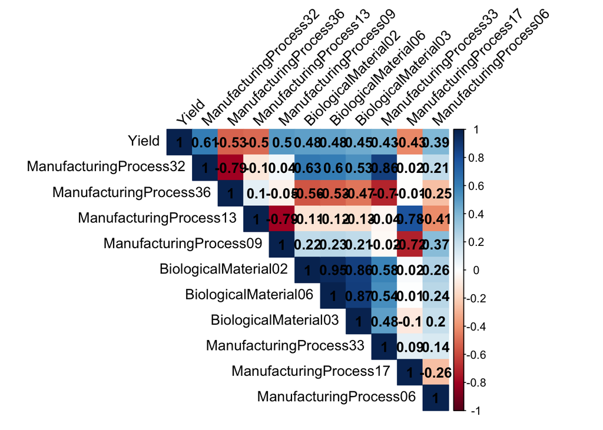

The correlation plot indicates that `ManufacturingProcess32` has the highest positive correlation with Yield. Notably, three of the top ten variables show a negative correlation with Yield. This insight can be valuable for future manufacturing runs, highlighting the predictors that significantly impact yield. To maximize or improve yield, it is advisable to enhance the measurements of both the manufacturing process and the biological properties of the raw materials.

## Exercise 7.2

Friedman (1991) introduced several benchmark data sets create by simulation. One of these simulations used the following nonlinear equation to create data:

$$y = 10 \sin(\pi x_1 x_2) + 20 (x_3 -
0.5)^2 + 10 x_4 + 5 x_5 + N(0, \sigma^2)$$

where the x values are random variables uniformly distributed between [0, 1] (there are also 5 other non-informative variables also created in the simulation). The package mlbench contains a function called mlbench.friedman1 that simulates these data:

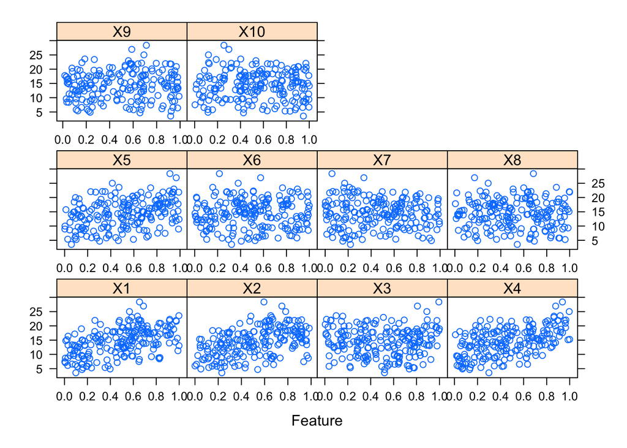

Tune several models on these data.

#### KNN

```
## k-Nearest Neighbors
##
## 200 samples
##  10 predictor
##
## Pre-processing: centered (10), scaled (10)
## Resampling: Bootstrapped (25 reps)
## Summary of sample sizes: 200, 200, 200, 200, 200, 200, ...
## Resampling results across tuning parameters:
##
##   k   RMSE      Rsquared   MAE
##    5  3.466085  0.5121775  2.816838
##    7  3.349428  0.5452823  2.727410
##    9  3.264276  0.5785990  2.660026
##   11  3.214216  0.6024244  2.603767
##   13  3.196510  0.6176570  2.591935
##   15  3.184173  0.6305506  2.577482
##   17  3.183130  0.6425367  2.567787
##   19  3.198752  0.6483184  2.592683
##   21  3.188993  0.6611428  2.588787
##   23  3.200458  0.6638353  2.604529
##
## RMSE was used to select the optimal model using the smallest value.
## The final value used for the model was k = 17.
```

#### NN

```
## Neural Network
##
## 200 samples
##  10 predictor
##
## Pre-processing: centered (10), scaled (10)
## Resampling: Cross-Validated (10 fold)
## Summary of sample sizes: 180, 180, 180, 180, 180, 180, ...
## Resampling results across tuning parameters:
##
##   decay  size  RMSE      Rsquared   MAE
##   0.00    1    2.472258  0.7361337  1.946237
##   0.00    2    2.598695  0.7235507  2.050188
##   0.00    3    2.289361  0.7856391  1.857798
##   0.00    4    2.383914  0.7634881  1.877946
##   0.00    5    2.663722  0.7389583  2.110590
##   0.00    6    3.905065  0.6259014  2.610159
##   0.00    7    5.347162  0.5165924  3.304978
##   0.00    8    5.182572  0.4773771  3.282141
##   0.00    9    3.698744  0.6050002  2.907096
##   0.00   10    8.409461  0.3914883  4.731788
##   0.01    1    2.381007  0.7641700  1.871466
##   0.01    2    2.589463  0.7298992  2.052240
##   0.01    3    2.149663  0.8043669  1.700742
##   0.01    4    2.581741  0.7251690  2.060772
##   0.01    5    2.552497  0.7241393  2.087569
##   0.01    6    2.725911  0.7274210  2.124363
##   0.01    7    3.088292  0.6514063  2.455271
##   0.01    8    3.254271  0.6199890  2.606086
##   0.01    9    3.287720  0.6234411  2.573698
##   0.01   10    3.201811  0.6355233  2.580708
##   0.10    1    2.392302  0.7614537  1.873847
##   0.10    2    2.516063  0.7411240  1.959889
##   0.10    3    2.300698  0.7631105  1.799187
##   0.10    4    2.420103  0.7688272  1.973456
##   0.10    5    2.376904  0.7815434  1.884561
##   0.10    6    2.299171  0.7848155  1.810647
##   0.10    7    2.664183  0.7431247  2.118045
##   0.10    8    3.000542  0.6869764  2.390558
##   0.10    9    3.155970  0.6576721  2.529023
##   0.10   10    3.152572  0.6774157  2.534086
##
## RMSE was used to select the optimal model using the smallest value.
## The final values used for the model were size = 3 and decay = 0.01.
```

#### MARS

```
## Multivariate Adaptive Regression Spline
##
## 200 samples
##  10 predictor
##
## No pre-processing
## Resampling: Cross-Validated (10 fold)
## Summary of sample sizes: 180, 180, 180, 180, 180, 180, ...
## Resampling results across tuning parameters:
##
##   degree  nprune  RMSE      Rsquared   MAE
##   1        2      4.188280  0.3042527  3.460689
##   1        3      3.551182  0.4999832  2.837116
##   1        4      2.653143  0.7167280  2.128222
##   1        5      2.405769  0.7562160  1.948161
```

[output cut: 73 more lines]

#### SVM

```
## Support Vector Machines with Radial Basis Function Kernel
##
## 200 samples
##  10 predictor
##
## Pre-processing: centered (10), scaled (10)
## Resampling: Cross-Validated (10 fold)
## Summary of sample sizes: 180, 180, 180, 180, 180, 180, ...
## Resampling results across tuning parameters:
##
##   C        RMSE      Rsquared   MAE
##      0.25  2.525164  0.7810576  2.010680
##      0.50  2.270567  0.7944850  1.794902
##      1.00  2.099367  0.8155571  1.659401
##      2.00  2.005858  0.8302852  1.578799
##      4.00  1.934587  0.8435759  1.528340
##      8.00  1.915672  0.8475581  1.528584
##     16.00  1.923940  0.8463025  1.536049
##     32.00  1.923940  0.8463025  1.536049
##     64.00  1.923940  0.8463025  1.536049
##    128.00  1.923940  0.8463025  1.536049
##    256.00  1.923940  0.8463025  1.536049
##    512.00  1.923940  0.8463025  1.536049
##   1024.00  1.923940  0.8463025  1.536049
##   2048.00  1.923940  0.8463025  1.536049
##
## Tuning parameter 'sigma' was held constant at a value of 0.06299324
## RMSE was used to select the optimal model using the smallest value.
## The final values used for the model were sigma = 0.06299324 and C = 8.
```

### Which models appear to give the best performance? Does MARS select the informative predictors (those named X1–X5)?

```
##      RMSE  Rsquared       MAE
## 2.0541197 0.8290353 1.5586411
```

MARS appears to give the best performance since it has the lowest RMSE and MAE and highest $R^2$. The second best would be SVM radial.

```
## earth variable importance
##
##    Overall
## X1  100.00
## X4   75.24
## X2   48.74
## X5   15.53
## X3    0.00
```

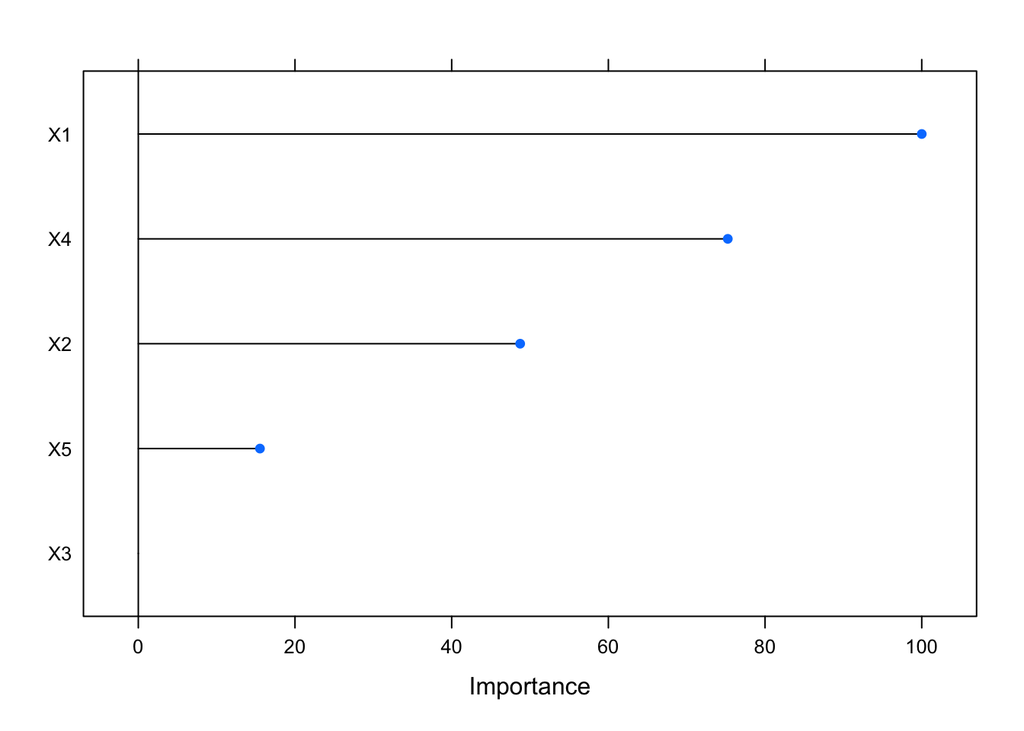

MARS successfully identifies the informative variables X1 through X5. However, X3 appears to be insignificant, with an importance value of approximately 0.

## Exercise 7.5.

Exercise 6.3 describes data for a chemical manufacturing process. Use the same data imputation, data splitting, and pre-processing steps as before and train several nonlinear regression models.

**a** - Which nonlinear regression model gives the optimal resampling and test set performance?

#### KNN

```
## k-Nearest Neighbors
##
## 144 samples
##  56 predictor
##
## Pre-processing: centered (56), scaled (56)
## Resampling: Bootstrapped (25 reps)
## Summary of sample sizes: 144, 144, 144, 144, 144, 144, ...
## Resampling results across tuning parameters:
##
##   k   RMSE      Rsquared   MAE
##    5  1.342348  0.4602587  1.042687
##    7  1.352680  0.4514484  1.049563
##    9  1.361908  0.4423328  1.064584
##   11  1.387181  0.4222218  1.095024
##   13  1.392705  0.4202866  1.096503
##   15  1.398380  0.4150837  1.104422
##   17  1.408527  0.4098765  1.110656
##   19  1.428280  0.3941756  1.132200
##   21  1.439355  0.3861658  1.140426
##   23  1.447654  0.3806335  1.152216
##
## RMSE was used to select the optimal model using the smallest value.
## The final value used for the model was k = 5.
```

#### NN

```
## Neural Network
##
## 144 samples
##  35 predictor
##
## Pre-processing: centered (35), scaled (35)
## Resampling: Cross-Validated (10 fold)
## Summary of sample sizes: 130, 129, 129, 130, 131, 131, ...
## Resampling results across tuning parameters:
##
##   decay  size  RMSE      Rsquared    MAE
##   0.00    1    1.671029  0.19930097  1.366807
##   0.00    2    2.249072  0.20300152  1.705681
##   0.00    3    2.461417  0.26738559  1.976176
##   0.00    4    2.899899  0.30550808  2.257237
##   0.00    5    3.040683  0.25032317  2.418776
##   0.00    6    3.516718  0.16727039  2.667052
##   0.00    7    6.530673  0.14979515  4.588962
##   0.00    8    5.410569  0.11561483  4.030111
##   0.00    9    6.383240  0.12347393  4.352107
##   0.00   10    7.585486  0.20325584  4.938742
##   0.01    1    1.599835  0.42308442  1.293237
##   0.01    2    1.698481  0.36004078  1.352505
##   0.01    3    2.583591  0.19755795  1.982149
##   0.01    4    2.888710  0.16972665  2.307564
##   0.01    5    2.682726  0.13400608  2.173206
##   0.01    6    2.630268  0.18280673  1.986049
##   0.01    7    2.569892  0.29663856  2.084018
##   0.01    8    2.729259  0.09472992  2.194297
##   0.01    9    2.944882  0.26175847  2.336383
##   0.01   10    2.552107  0.28250399  2.089189
##   0.10    1    1.362412  0.47108215  1.084493
##   0.10    2    1.698359  0.42539735  1.320210
##   0.10    3    2.701196  0.17337905  1.851533
##   0.10    4    2.538072  0.28943434  2.024931
##   0.10    5    2.179598  0.29945025  1.645687
##   0.10    6    2.512213  0.33206383  1.848322
##   0.10    7    2.591221  0.24356507  1.887794
##   0.10    8    2.138723  0.33609047  1.631368
##   0.10    9    2.130417  0.32516282  1.583381
##   0.10   10    2.264613  0.33009011  1.853339
##
## RMSE was used to select the optimal model using the smallest value.
## The final values used for the model were size = 1 and decay = 0.1.
```

#### MARS

```
## Multivariate Adaptive Regression Spline
##
## 144 samples
##  56 predictor
##
## No pre-processing
## Resampling: Cross-Validated (10 fold)
## Summary of sample sizes: 130, 129, 129, 130, 131, 131, ...
## Resampling results across tuning parameters:
##
##   degree  nprune  RMSE      Rsquared   MAE
##   1        2      1.358846  0.4736659  1.0773044
##   1        3      1.268370  0.5358443  1.0373274
##   1        4      1.267084  0.5314379  1.0400187
##   1        5      1.296629  0.4999367  1.0642226
```

[output cut: 73 more lines]

#### SVM

```
## Support Vector Machines with Radial Basis Function Kernel
##
## 144 samples
##  56 predictor
##
## Pre-processing: centered (56), scaled (56)
## Resampling: Cross-Validated (10 fold)
## Summary of sample sizes: 130, 129, 129, 130, 131, 131, ...
## Resampling results across tuning parameters:
##
##   C        RMSE      Rsquared   MAE
##      0.25  1.366871  0.4897753  1.1123793
##      0.50  1.265913  0.5393553  1.0231671
##      1.00  1.169552  0.6067533  0.9326343
##      2.00  1.131844  0.6388397  0.9000584
##      4.00  1.128786  0.6412006  0.9029134
##      8.00  1.130872  0.6379454  0.8988309
##     16.00  1.125335  0.6412233  0.8936723
##     32.00  1.125335  0.6412233  0.8936723
##     64.00  1.125335  0.6412233  0.8936723
##    128.00  1.125335  0.6412233  0.8936723
##    256.00  1.125335  0.6412233  0.8936723
##    512.00  1.125335  0.6412233  0.8936723
##   1024.00  1.125335  0.6412233  0.8936723
##   2048.00  1.125335  0.6412233  0.8936723
##
## Tuning parameter 'sigma' was held constant at a value of 0.01360118
## RMSE was used to select the optimal model using the smallest value.
## The final values used for the model were sigma = 0.01360118 and C = 16.
```

## let’s rebind them togather

```
##          RMSE  Rsquared       MAE
## knn  1.601595 0.4327268 1.2948125
## nn   1.734023 0.3053244 1.4465031
## mars 1.310651 0.6026766 1.0363215
## svmR 1.324883 0.6268963 0.9948799
```

Based on these metrics, svmR appears to be the optimal choice among the models evaluated in terms of predictive performance for the given chemical manufacturing process dataset.

**(b)** - Which predictors are most important in the optimal nonlinear regres- sion model? Do either the biological or process variables dominate the list? How do the top ten important predictors compare to the top ten predictors from the optimal linear model?

```
## loess r-squared variable importance
##
##   only 20 most important variables shown (out of 56)
##
##                        Overall
## ManufacturingProcess32  100.00
## BiologicalMaterial06     87.81
## ManufacturingProcess13   78.23
## BiologicalMaterial03     76.45
## ManufacturingProcess36   69.41
## BiologicalMaterial12     69.16
## ManufacturingProcess17   68.44
## ManufacturingProcess31   66.57
## ManufacturingProcess09   64.12
## ManufacturingProcess06   60.79
## BiologicalMaterial02     53.50
## ManufacturingProcess29   51.92
## BiologicalMaterial11     48.66
## ManufacturingProcess33   47.79
## ManufacturingProcess11   43.74
## ManufacturingProcess30   43.02
## BiologicalMaterial09     38.34
## BiologicalMaterial04     37.89
## BiologicalMaterial08     36.89
## ManufacturingProcess12   36.53
```

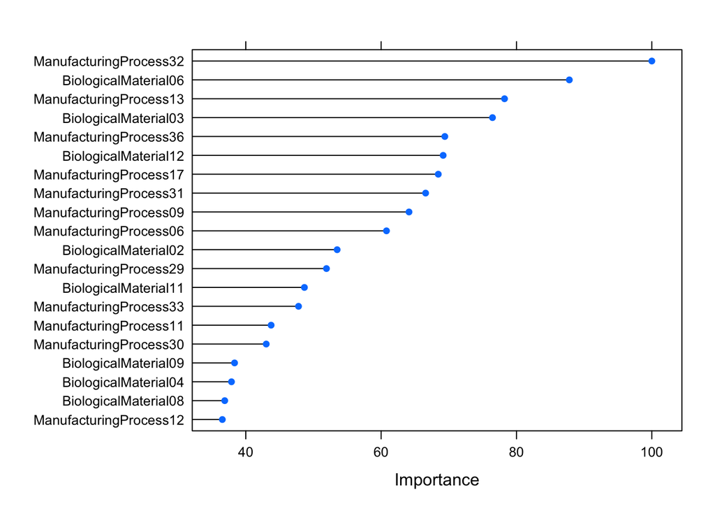

**(c)** - Explore the relationships between the top predictors and the response for the predictors that are unique to the optimal nonlinear regression model. Do these plots reveal intuition about the biological or process predictors and their relationship with yield?

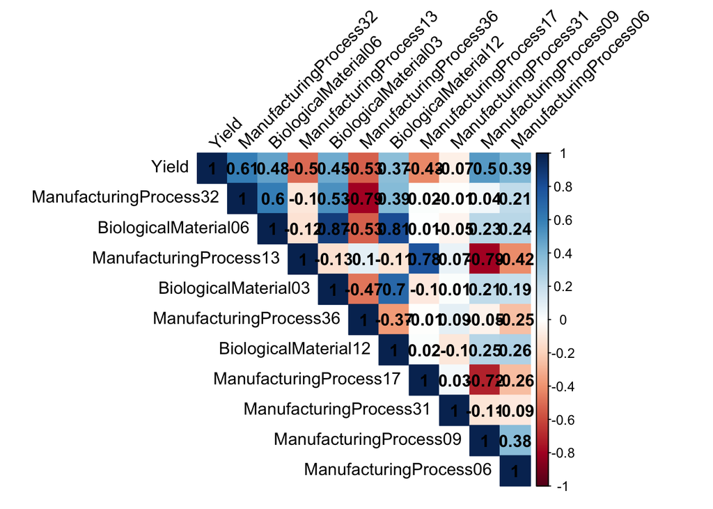

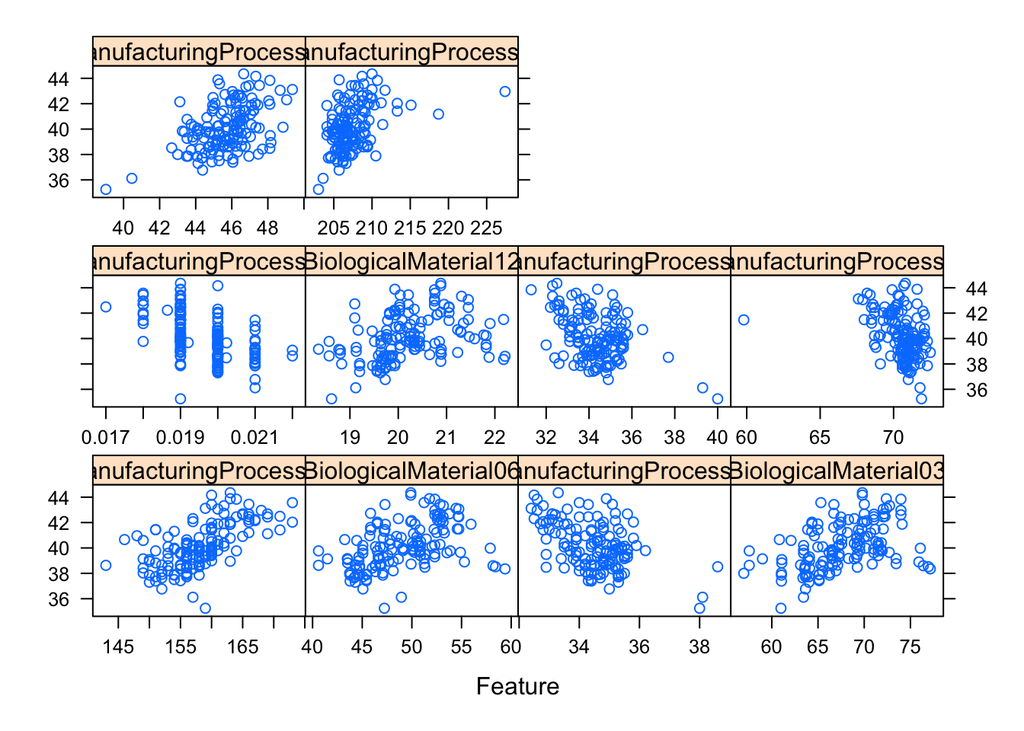

It appears that `the biological predictors` generally exhibit a positive relationship with yield, whereas the relationships of `manufacturing processes` with yield vary. For example, `ManufacturingProcess31` tends to cluster around a specific value, whereas `ManufacturingProcess36` shows distinct levels.